# Notebook Statistical Testing R Data Cafe

Kees Mulder

November 13, 2017

## Statistical testing in R

First, we’ll create a data set that has only observed ozone values. Note that this data is temporally dependent, which we’ll ignore for demonstration purposes.

```r
library(ggplot2)
library(dplyr)
# Select
aq_obs <- airquality[complete.cases(airquality), ]
```

## ANOVA-type testing

First, we’ll make a new variable that denotes whether the day had a high or low temperature. We can use the R function `cut`.

```r
aq_obs$HighTemperature <- cut(aq_obs$Temp, breaks = 2, labels = c("Cold", "Hot"))

aq_obs$HighTemperature
```

```
##   [1] Cold Cold Cold Cold Cold Cold Cold Cold Cold Cold Cold Cold Cold Cold
##  [15] Cold Cold Cold Cold Cold Cold Cold Hot  Hot  Cold Hot  Hot  Hot  Hot
##  [29] Cold Cold Cold Cold Cold Hot  Hot  Hot  Hot  Hot  Hot  Hot  Hot  Hot
##  [43] Cold Hot  Hot  Hot  Hot  Hot  Hot  Hot  Cold Hot  Hot  Hot  Hot  Hot
##  [57] Hot  Hot  Hot  Hot  Hot  Hot  Hot  Hot  Hot  Hot  Hot  Hot  Cold Hot
##  [71] Cold Hot  Hot  Cold Cold Hot  Hot  Hot  Hot  Hot  Hot  Hot  Hot  Hot
##  [85] Hot  Hot  Hot  Hot  Hot  Hot  Cold Cold Hot  Cold Cold Cold Cold Hot
##  [99] Cold Cold Cold Hot  Cold Cold Hot  Cold Cold Cold Cold Cold Cold
## Levels: Cold Hot
```

An ANOVA asks the question of whether two groups differ. In this case, we are interested in whether or not there is more ozone on hot rather than cold days. First, let’s look at the summary statistics. I’ll use [`dplyr`](https://cran.r-project.org/web/packages/dplyr/vignettes/dplyr.html) and `ggplot2`, but don’t worry if you’re not familiar.

```r
aq_obs %>% group_by(HighTemperature) %>% summarize(mean(Ozone), median(Ozone), min(Ozone), max(Ozone))
```

```
## # A tibble: 2 x 5
##   HighTemperature `mean(Ozone)` `median(Ozone)` `min(Ozone)` `max(Ozone)`
##            <fctr>         <dbl>           <dbl>        <dbl>        <dbl>
## 1            Cold      18.66000              18            1           41
## 2             Hot      61.31148              59            7          168
```

The groups seem quite different. We can visualize this by running:

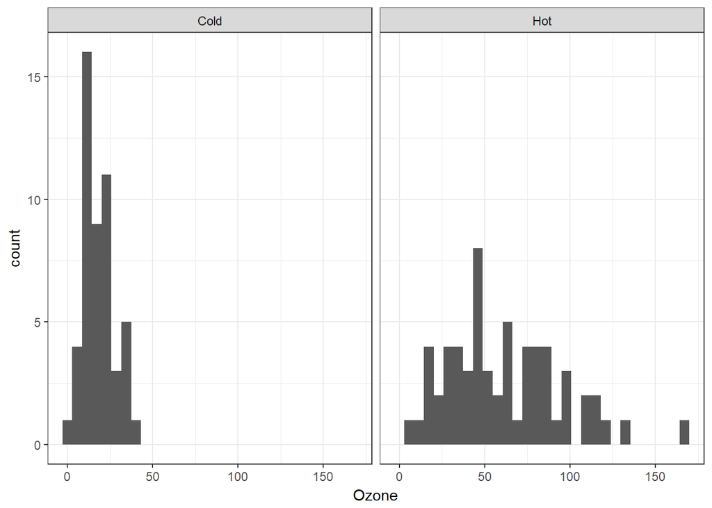

```r
ggplot(aq_obs, aes(x = Ozone)) + geom_histogram() + facet_wrap(~HighTemperature) + theme_bw()
```

The statistical test can be done by `aov`. NOTE: R has some fairly confusing terminology, because it has both functions `anova` and `aov`. The typical ANOVA is done using `aov`. The function `anova` is used to compare different models. I’ll show how they relate below in a later section.

```r
aq_anova_model <- aov(Ozone ~ HighTemperature, data = aq_obs)
aq_anova_model
```

```
## Call:
##    aov(formula = Ozone ~ HighTemperature, data = aq_obs)
##
## Terms:
##                 HighTemperature Residuals
## Sum of Squares         49985.61  71816.30
## Deg. of Freedom               1       109
##
## Residual standard error: 25.66837
## Estimated effects may be unbalanced
```

This does provide the typical ANOVA table, but no significance test. We can obtain that by:

```r
summary(aq_anova_model)
```

```
##                  Df Sum Sq Mean Sq F value   Pr(>F)
## HighTemperature   1  49986   49986   75.87 3.68e-14 ***
## Residuals       109  71816     659
## ---
## Signif. codes:  0 '***' 0.001 '**' 0.01 '*' 0.05 '.' 0.1 ' ' 1
```

Clearly, the groups differ.

## Regression

A regression has a continuous outcome and some set of categorical and continuous predictors. A regression analysis in `R` is simply performed by the `lm()` command, and statistical tests are provided. Let’s look at a plot first:

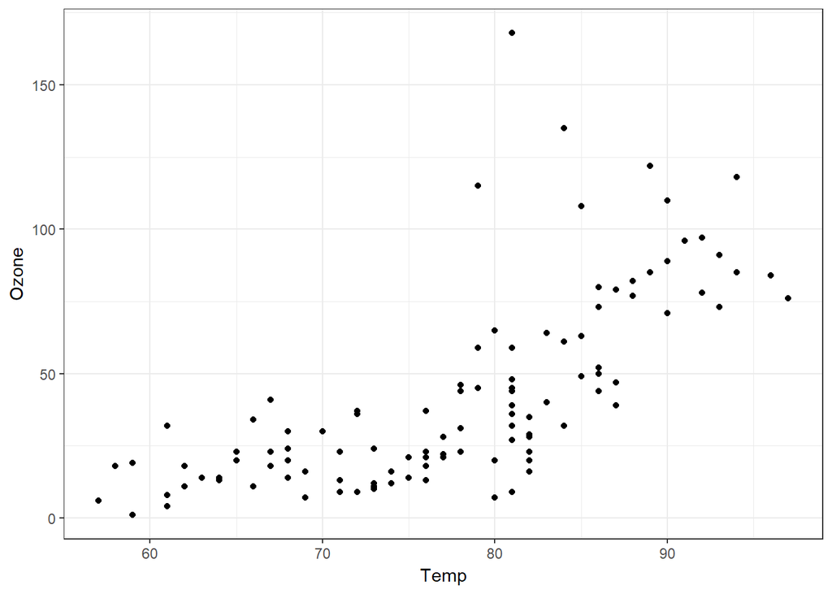

```r
ggplot(aq_obs, aes(x = Temp, y = Ozone)) + geom_point() + theme_bw()
```

```r
temp_lm <- lm(Ozone ~ Temp, data = aq_obs)

summary(temp_lm)
```

```
##
## Call:
## lm(formula = Ozone ~ Temp, data = aq_obs)
##
## Residuals:
##     Min      1Q  Median      3Q     Max
## -40.922 -17.459  -0.874  10.444 118.078
##
## Coefficients:
##              Estimate Std. Error t value Pr(>|t|)
## (Intercept) -147.6461    18.7553  -7.872 2.76e-12 ***
## Temp           2.4391     0.2393  10.192  < 2e-16 ***
## ---
## Signif. codes:  0 '***' 0.001 '**' 0.01 '*' 0.05 '.' 0.1 ' ' 1
##
## Residual standard error: 23.92 on 109 degrees of freedom
## Multiple R-squared:  0.488,  Adjusted R-squared:  0.4833
## F-statistic: 103.9 on 1 and 109 DF,  p-value: < 2.2e-16
```

Temperature is definitely a signficant predictor. Checking assumptions can be done through the running `plot` on the `lm` outcome object:

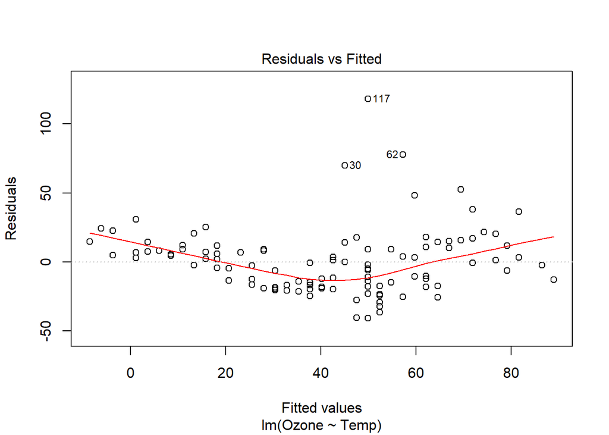

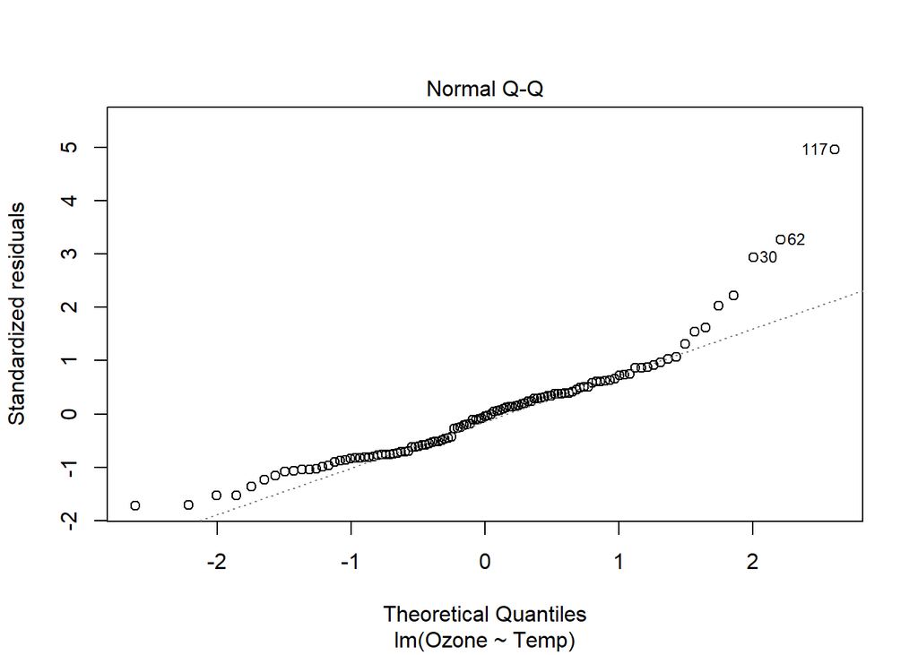

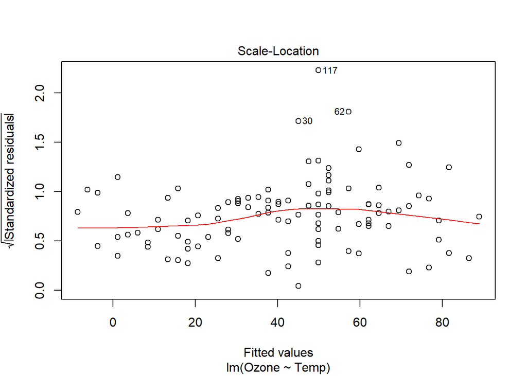

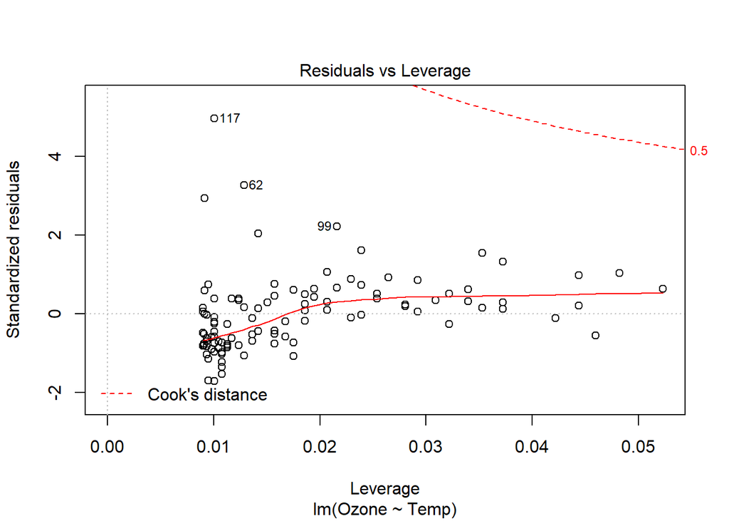

```r
plot(temp_lm)
```

Note that the residuals are note nicely distributed and the QQ-plots also leave something to be desired. A transformation might be in order.

Transformations can easily be applied in the formula syntax. For example:

```r
temp_log_lm <- lm(log(Ozone) ~ Temp, data = aq_obs)

summary(temp_log_lm)
```

```
##
## Call:
## lm(formula = log(Ozone) ~ Temp, data = aq_obs)
##
## Residuals:
##      Min       1Q   Median       3Q      Max
## -2.14417 -0.32555  0.02066  0.34234  1.49100
##
## Coefficients:
##              Estimate Std. Error t value Pr(>|t|)
## (Intercept) -1.848518   0.455080  -4.062  9.2e-05 ***
## Temp         0.067673   0.005807  11.654  < 2e-16 ***
## ---
## Signif. codes:  0 '***' 0.001 '**' 0.01 '*' 0.05 '.' 0.1 ' ' 1
##
## Residual standard error: 0.5804 on 109 degrees of freedom
## Multiple R-squared:  0.5548, Adjusted R-squared:  0.5507
## F-statistic: 135.8 on 1 and 109 DF,  p-value: < 2.2e-16
```

Note that the R-squared has increased by taking the log, suggesting that this model fits better. Interactions can also be added easily:

```r
temp_log_interaction_lm <- lm(log(Ozone) ~ Temp*Wind, data = aq_obs)
summary(temp_log_interaction_lm)
```

```
##
## Call:
## lm(formula = log(Ozone) ~ Temp * Wind, data = aq_obs)
##
## Residuals:
##      Min       1Q   Median       3Q      Max
## -2.31151 -0.28199  0.05219  0.34752  1.12276
##
## Coefficients:
##              Estimate Std. Error t value Pr(>|t|)
## (Intercept) -2.380182   1.306868  -1.821   0.0714 .
## Temp         0.081641   0.015953   5.118 1.37e-06 ***
## Wind         0.135132   0.115136   1.174   0.2431
## Temp:Wind   -0.002509   0.001465  -1.713   0.0896 .
## ---
## Signif. codes:  0 '***' 0.001 '**' 0.01 '*' 0.05 '.' 0.1 ' ' 1
##
## Residual standard error: 0.5475 on 107 degrees of freedom
## Multiple R-squared:  0.6111, Adjusted R-squared:  0.6002
## F-statistic: 56.04 on 3 and 107 DF,  p-value: < 2.2e-16
```

Note that we automatically get the intercept and the main effects. All can also be turned off.

For quadratic (and higher powers) transformations, we need to use `I()` around the variable:

```r
temp_log_quadratic_lm <- lm(log(Ozone) ~ Temp + Wind + I(Wind^2), data = aq_obs)
summary(temp_log_quadratic_lm)
```

```
##
## Call:
## lm(formula = log(Ozone) ~ Temp + Wind + I(Wind^2), data = aq_obs)
##
## Residuals:
##      Min       1Q   Median       3Q      Max
## -2.33247 -0.29239  0.02772  0.33888  1.16807
##
## Coefficients:
##              Estimate Std. Error t value Pr(>|t|)
## (Intercept)  0.579697   0.706053   0.821  0.41345
## Temp         0.053895   0.006318   8.531 1.05e-13 ***
## Wind        -0.215922   0.065471  -3.298  0.00132 **
## I(Wind^2)    0.007093   0.002879   2.464  0.01534 *
## ---
## Signif. codes:  0 '***' 0.001 '**' 0.01 '*' 0.05 '.' 0.1 ' ' 1
##
## Residual standard error: 0.5399 on 107 degrees of freedom
## Multiple R-squared:  0.6219, Adjusted R-squared:  0.6113
## F-statistic: 58.66 on 3 and 107 DF,  p-value: < 2.2e-16
```

## Relationship between ANOVA and regression

As you may know, ANOVA and regression are deeply related concepts. In R, we can easily show how these are related. An ANOVA table is computed by comparing how much residual variance (which you can think of as unexplained error) there is left after incorporating predictors in a model. Here, we can show this by computing two regression models:

```r
icpt_model <- lm(Ozone ~ 1, data = aq_obs)
temp_model <- lm(Ozone ~ HighTemperature, data = aq_obs)
```

The first does not have any predictors, and the second does have a categorical predictor. The ANOVA compares how well these models each predict the outcome, and compares this. Look at the output of the `aov` model fit first, and then at the model comparison of the two regression models by means of the `anova()` function, and see that the results are exactly the same:

```r
summary(aq_anova_model)
```

```
##                  Df Sum Sq Mean Sq F value   Pr(>F)
## HighTemperature   1  49986   49986   75.87 3.68e-14 ***
## Residuals       109  71816     659
## ---
## Signif. codes:  0 '***' 0.001 '**' 0.01 '*' 0.05 '.' 0.1 ' ' 1
```

```r
# Two regressions as input gives the same result.
anova(icpt_model, temp_model)
```

```
## Analysis of Variance Table
##
## Model 1: Ozone ~ 1
## Model 2: Ozone ~ HighTemperature
##   Res.Df    RSS Df Sum of Sq      F    Pr(>F)
## 1    110 121802
## 2    109  71816  1     49986 75.866 3.683e-14 ***
## ---
## Signif. codes:  0 '***' 0.001 '**' 0.01 '*' 0.05 '.' 0.1 ' ' 1
```

It should be clear that this means that we can use the `anova` function also much more generally to compare any two nested models tested on the same dataset:

```r
wind_model <- lm(Ozone ~ HighTemperature + Wind, data = aq_obs)
interaction_model <- lm(Ozone ~ HighTemperature + Wind + HighTemperature*Wind, data = aq_obs)


anova(icpt_model, temp_model, wind_model, interaction_model)
```

```
## Analysis of Variance Table
##
## Model 1: Ozone ~ 1
## Model 2: Ozone ~ HighTemperature
## Model 3: Ozone ~ HighTemperature + Wind
## Model 4: Ozone ~ HighTemperature + Wind + HighTemperature * Wind
##   Res.Df    RSS Df Sum of Sq       F    Pr(>F)
## 1    110 121802
## 2    109  71816  1     49986 121.564 < 2.2e-16 ***
## 3    108  54437  1     17379  42.265 2.606e-09 ***
## 4    107  43997  1     10440  25.390 1.915e-06 ***
## ---
## Signif. codes:  0 '***' 0.001 '**' 0.01 '*' 0.05 '.' 0.1 ' ' 1
```

Our conclusion is that all of these models improve on the previous one, so we the most complex model is the best.

## ANCOVA

Usually, you would perform an analysis of covariance (ANCOVA) in the regression context. For example:

```r
ancova_type_mod <- lm(log(Ozone) ~ Temp + Wind, data = aq_obs)
summary(ancova_type_mod)
```

```
##
## Call:
## lm(formula = log(Ozone) ~ Temp + Wind, data = aq_obs)
##
## Residuals:
##      Min       1Q   Median       3Q      Max
## -2.36759 -0.25774  0.05869  0.35009  1.16747
##
## Coefficients:
##             Estimate Std. Error t value Pr(>|t|)
## (Intercept) -0.38742    0.60050  -0.645 0.520189
## Temp         0.05655    0.00637   8.878 1.64e-14 ***
## Wind        -0.05993    0.01706  -3.513 0.000649 ***
## ---
## Signif. codes:  0 '***' 0.001 '**' 0.01 '*' 0.05 '.' 0.1 ' ' 1
##
## Residual standard error: 0.5524 on 108 degrees of freedom
## Multiple R-squared:  0.6004, Adjusted R-squared:  0.593
## F-statistic: 81.14 on 2 and 108 DF,  p-value: < 2.2e-16
```

## GLM

We can easily fit a GLM using the `glm()` function. Let’s show it by predicting the dichotomous temperature variable in a logisitic regression.

```r
aq_glm <- glm(HighTemperature ~ Ozone, data = aq_obs, family = binomial(link = "logit"))

summary(aq_glm)
```

```
##
## Call:
## glm(formula = HighTemperature ~ Ozone, family = binomial(link = "logit"),
##     data = aq_obs)
##
## Deviance Residuals:
##      Min        1Q    Median        3Q       Max
## -1.78315  -0.58183   0.01061   0.41702   2.38701
##
## Coefficients:
##             Estimate Std. Error z value Pr(>|z|)
## (Intercept) -3.64385    0.72539  -5.023 5.08e-07 ***
## Ozone        0.12209    0.02491   4.901 9.54e-07 ***
## ---
## Signif. codes:  0 '***' 0.001 '**' 0.01 '*' 0.05 '.' 0.1 ' ' 1
##
## (Dispersion parameter for binomial family taken to be 1)
##
##     Null deviance: 152.787  on 110  degrees of freedom
## Residual deviance:  77.125  on 109  degrees of freedom
## AIC: 81.125
##
## Number of Fisher Scoring iterations: 7
```

## Bayesian models

Nowadays, if you want to make your GLM Bayesian, you can very easily do it with the `brms` package: just replace `glm` or `lm` by `brm`.

```r
library(brms)
aq_bayes_glm <- brm(Ozone ~ Temp, data = aq_obs)

summary(aq_bayes_glm)
```

[output not shown]